# Analysis of coverage in capture experiments

## Distance Matrix from inferred phylogeny

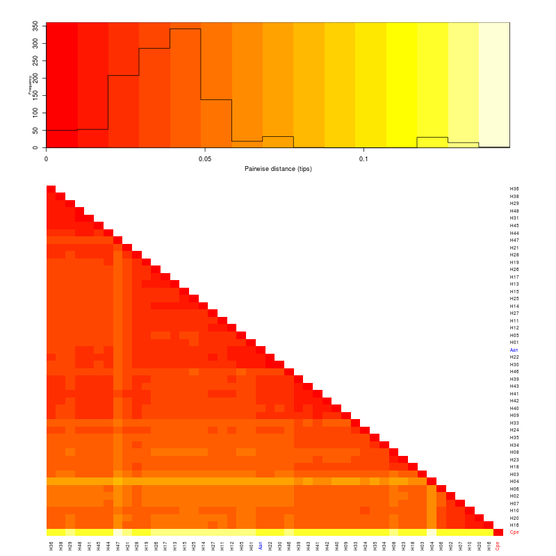

Distance matrix

## Detailed

Map2 - target

Coverage overview

`map2Aan`

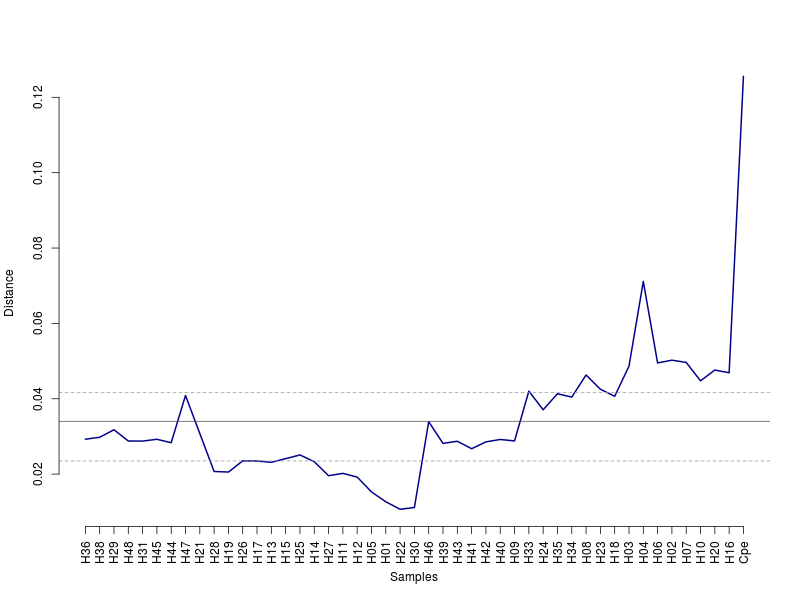

`map2Swift`

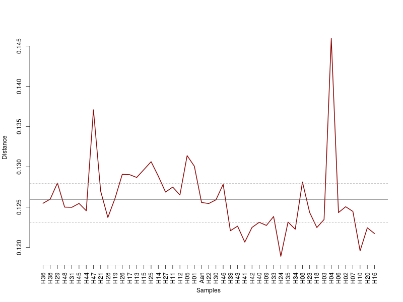

## Depth of coverage vs. phylogenetic distance

This has been done following Bragg’s paper, where depth of coverage is related to phylogenetic distance. It shows the median, plus or minus the 1st. and 3rd. quartiles, out of 46 samples.

### Mapped to outgroup

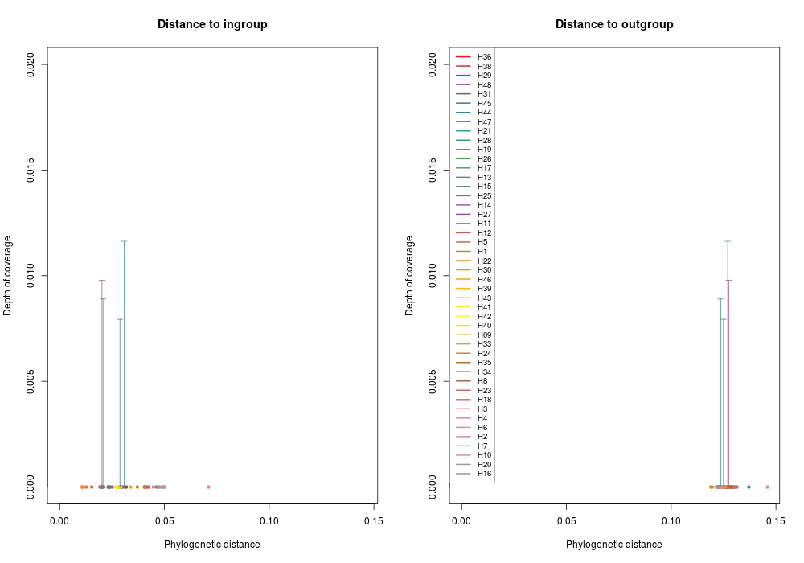

Coverage vs. distance - map2Swift

### Mapped to ingroup

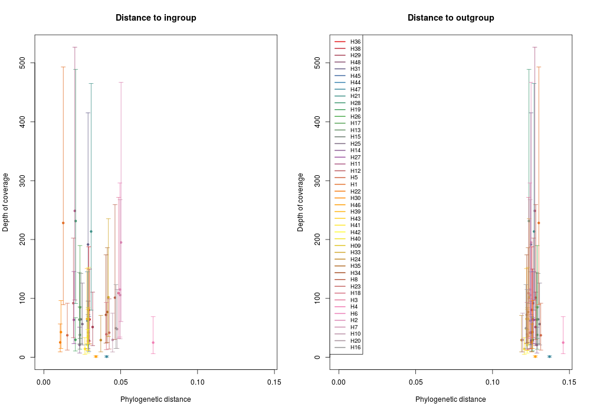

Coverage vs. distance - map2Aan

## Correlations

Only information related to dataset mapped to ingroup. It was not possible to get information from the other dataset because the standard deviations are 0. Also, we can see that there’s no linear correlation between the distance and the coverage obtained from the experiment.

|  | Correlation.Coefficient | Corr..Squared | Spearman.corr. |
| --- | --- | --- | --- |
| Distance to ingroup | -0.0790755 | 0.0062529 | 0.0548258 |
| Distance to outgroup | -0.0318779 | 0.0010162 | 0.0364477 |